# Week 1: Statistical Foundations and Study Design

## 3.4 The Arbitrary Nature of p < 0.05

Where did p < 0.05 come from? It was popularized by statistician R.A. Fisher in the 1920s as a **convenient convention**, not a law of nature. He even cautioned against treating it as a bright-line rule.

### 3.4.1 The Problem with Bright Lines

Consider three studies comparing the same feed additive:

- **Study A**: p = 0.049 → “Significant! The additive works!”
- **Study B**: p = 0.051 → “Not significant. No evidence it works.”
- **Study C**: p = 0.048 → “Significant! Definitely works!”

Does it really make sense that Study A and C lead to completely different conclusions than Study B, when the p-values are nearly identical?

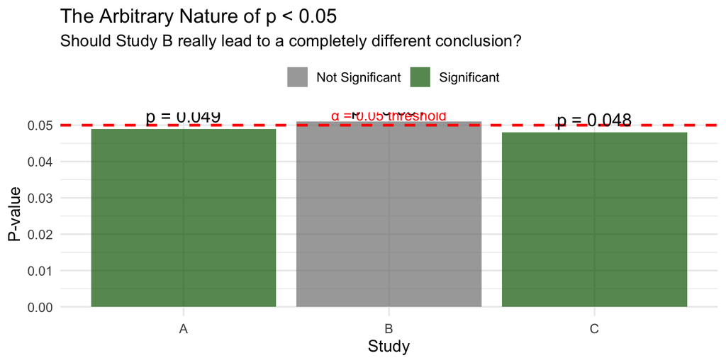

```r
# Visualize the arbitrary threshold
tibble(
  study = c("A", "B", "C"),
  p_value = c(0.049, 0.051, 0.048),
  significant = p_value < 0.05
) %>%
  ggplot(aes(x = study, y = p_value, fill = significant)) +
  geom_col(alpha = 0.7) +
  geom_hline(yintercept = 0.05, linetype = "dashed", color = "red", linewidth = 1) +
  geom_text(aes(label = sprintf("p = %.3f", p_value)), vjust = -0.5, size = 5) +
  annotate("text", x = 2, y = 0.05, label = "α = 0.05 threshold",
           color = "red", vjust = -0.5, size = 4) +
  scale_fill_manual(values = c("TRUE" = "darkgreen", "FALSE" = "gray50"),
                    labels = c("TRUE" = "Significant", "FALSE" = "Not Significant")) +
  labs(
    title = "The Arbitrary Nature of p < 0.05",
    subtitle = "Should Study B really lead to a completely different conclusion?",
    x = "Study",
    y = "P-value",
    fill = ""
  ) +
  theme_minimal(base_size = 13) +
  theme(legend.position = "top")
```

### 3.4.2 Modern Perspectives

Many scientific fields are moving away from rigid thresholds:

- **Report exact p-values** (e.g., p = 0.03, not just “p < 0.05”)
- **Focus on effect sizes and confidence intervals** more than p-values
- **Consider p-values as continuous measures** of evidence, not binary decisions
- Some journals now ban the term “statistically significant” entirely

**NoteWhat We’ll Do in This Course**

We’ll calculate p-values because they’re standard in animal science, but we’ll **always** interpret them alongside:

- Effect sizes (how big is the difference?)
- Confidence intervals (what’s the range of plausible values?)
- Practical significance (does the effect size matter in the real world?)

# 4 Study Design: Observational vs Experimental

Not all research is created equal. The **design** of a study fundamentally determines what conclusions you can draw, particularly about **causation**.

## 4.1 The Gold Standard: Causation vs Association

- **Association** (correlation): Two variables change together, but we don’t know if one causes the other
- **Causation**: Changing one variable **causes** changes in the other

The single most important question when reading research: **Can this study establish causation, or only association?**

### 4.1.1 Observational Studies

In an **observational study**, the researcher simply observes and records data **without manipulating** any variables. You measure what’s already happening naturally.

**Examples in animal science:**

1. **Cross-sectional survey**: Measure backfat thickness in pigs across different farms at one point in time
2. **Cohort study**: Follow beef cattle over time and record which ones develop health issues
3. **Case-control study**: Compare diet history of cattle with vs without liver abscesses

**Strengths:**

- Can study things we can’t (or shouldn’t) experimentally manipulate
- Often cheaper and faster than experiments
- Reflects real-world conditions
- Good for exploratory research and hypothesis generation

**Limitations:**

- **Cannot establish causation** (only association)
- **Confounding variables** can bias results (more on this below)
- Difficult to control for all alternative explanations

#### 4.1.1.1 Example: Farm Size and Pig Health

Imagine you survey 100 swine farms and find that **larger farms have lower mortality rates**.

**Can you conclude that increasing farm size causes better health outcomes?**

**No!** Many confounding variables could explain this:

- Larger farms might have better veterinary care
- They might use better biosecurity protocols
- They might have more experienced managers
- They might be in regions with different disease pressures
- Healthier farms might have expanded to become larger (reverse causation!)

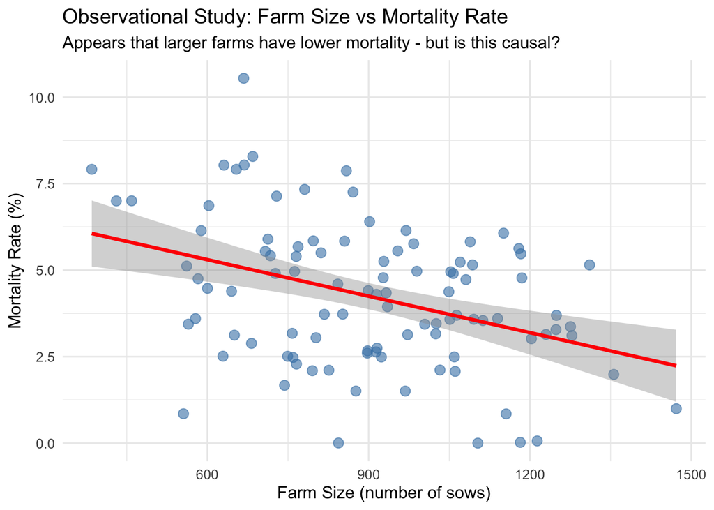

```r
# Simulate observational data with confounding
set.seed(321)
n_farms <- 100

# Management quality is a confounder
management_quality <- rnorm(n_farms, mean = 50, sd = 15)

# Better-managed farms tend to be larger (confounding)
farm_size <- 500 + 8 * management_quality + rnorm(n_farms, mean = 0, sd = 200)

# Mortality is affected by management quality, NOT farm size directly
mortality_rate <- 8 - 0.08 * management_quality + rnorm(n_farms, mean = 0, sd = 1.5)
mortality_rate <- pmax(0, mortality_rate)  # Can't be negative

farm_data <- tibble(
  farm_id = 1:n_farms,
  size = farm_size,
  mortality = mortality_rate,
  management = management_quality
)

# Naive analysis (ignoring confounding)
p3 <- ggplot(farm_data, aes(x = size, y = mortality)) +
  geom_point(alpha = 0.6, size = 3, color = "steelblue") +
  geom_smooth(method = "lm", se = TRUE, color = "red", linewidth = 1.2) +
  labs(
    title = "Observational Study: Farm Size vs Mortality Rate",
    subtitle = "Appears that larger farms have lower mortality - but is this causal?",
    x = "Farm Size (number of sows)",
    y = "Mortality Rate (%)"
  )

print(p3)
```

```r
cor_size_mort <- cor(farm_data$size, farm_data$mortality)
cat(sprintf("\nCorrelation between farm size and mortality: %.3f\n", cor_size_mort))
```

```
Correlation between farm size and mortality: -0.383
```

```r
cat("But this is driven by a confounder: management quality!\n")
```

```
But this is driven by a confounder: management quality!
```

This is **association, not causation**. To establish that farm size itself affects mortality, you’d need an experimental design.

### 4.1.2 Experimental Studies

In an **experimental study**, the researcher **actively manipulates** one or more variables (the “treatment” or “intervention”) and measures the effect on an outcome.

**Key features:**

- Researcher controls who receives which treatment
- Ideally uses **randomization** to assign treatments
- Controls other variables to isolate the effect of the treatment
- Can establish **causation** (if designed properly)

**Examples in animal science:**

1. **Feed trial**: Randomly assign piglets to Diet A vs Diet B, measure growth
2. **Drug efficacy trial**: Randomly assign cattle to antibiotic vs placebo, measure recovery
3. **Breeding experiment**: Randomly assign boars to breeding groups, compare offspring traits

#### 4.1.2.1 Example: Does Lysine Supplementation Improve Growth?

**Study design**: Take 60 pigs, **randomly** assign 30 to a control diet and 30 to a lysine-supplemented diet. Raise them identically otherwise. Measure final weight.

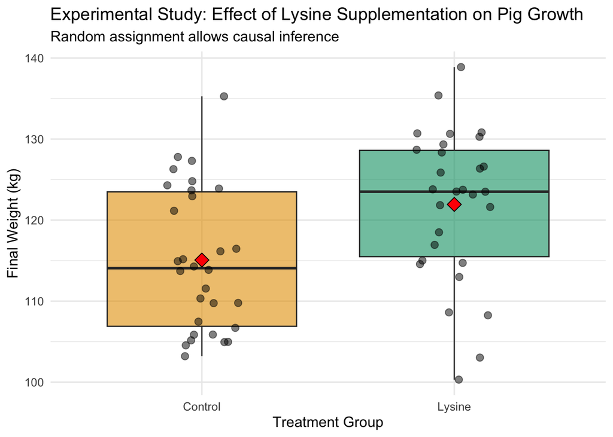

```r
# Simulate experimental data
set.seed(654)
n_pigs <- 60

# Randomly assign treatment
pig_data <- tibble(
  pig_id = 1:n_pigs,
  treatment = rep(c("Control", "Lysine"), each = n_pigs/2),
  # Lysine truly increases weight by ~8 kg
  final_weight = ifelse(treatment == "Control",
                       rnorm(n_pigs/2, mean = 115, sd = 12),
                       rnorm(n_pigs/2, mean = 115 + 8, sd = 12))
)

# Visualize
p4 <- ggplot(pig_data, aes(x = treatment, y = final_weight, fill = treatment)) +
  geom_boxplot(alpha = 0.6, outlier.shape = NA) +
  geom_jitter(width = 0.15, alpha = 0.5, size = 2.5) +
  stat_summary(fun = mean, geom = "point", shape = 23, size = 4, fill = "red") +
  scale_fill_manual(values = c("Control" = "#E69F00", "Lysine" = "#009E73")) +
  labs(
    title = "Experimental Study: Effect of Lysine Supplementation on Pig Growth",
    subtitle = "Random assignment allows causal inference",
    y = "Final Weight (kg)",
    x = "Treatment Group"
  ) +
  theme(legend.position = "none")

print(p4)
```

```r
# Test for difference
exp_test <- t.test(final_weight ~ treatment, data = pig_data)
cat(sprintf("\nMean difference: %.2f kg\n",
            mean(pig_data$final_weight[pig_data$treatment == "Lysine"]) -
            mean(pig_data$final_weight[pig_data$treatment == "Control"])))
```

```
Mean difference: 6.86 kg
```

```r
cat(sprintf("P-value: %.4f\n", exp_test$p.value))
```

```
P-value: 0.0044
```

```r
cat("\nBecause we RANDOMLY assigned treatments, we can conclude:\n")
```

```
Because we RANDOMLY assigned treatments, we can conclude:
```

```r
cat("Lysine supplementation CAUSES increased growth in pigs.\n")
```

```
Lysine supplementation CAUSES increased growth in pigs.
```

**Why can we claim causation here?**

Because of **randomization** (discussed in detail in the next section). Random assignment ensures that the two groups are equivalent on average at the start—any difference at the end must be due to the treatment.

## 4.2 Confounding Variables

A **confounding variable** (or confounder) is a variable that:

1. Is associated with the treatment/exposure
2. Independently affects the outcome
3. Is not on the causal pathway between treatment and outcome

Confounding creates **spurious associations**—relationships that appear causal but aren’t.

### 4.2.1 The Classic Example: Ice Cream and Drowning

This non-agricultural example illustrates confounding perfectly:

**Observation**: Ice cream sales are strongly correlated with drowning deaths.

**Conclusion**: Ice cream causes drowning?! Should we ban ice cream to save lives?

**Reality**: Both are caused by a confounder: **temperature/summer season**

- Hot weather → people buy ice cream
- Hot weather → people go swimming → more drownings

Ice cream and drowning are **associated** but not **causally related**.

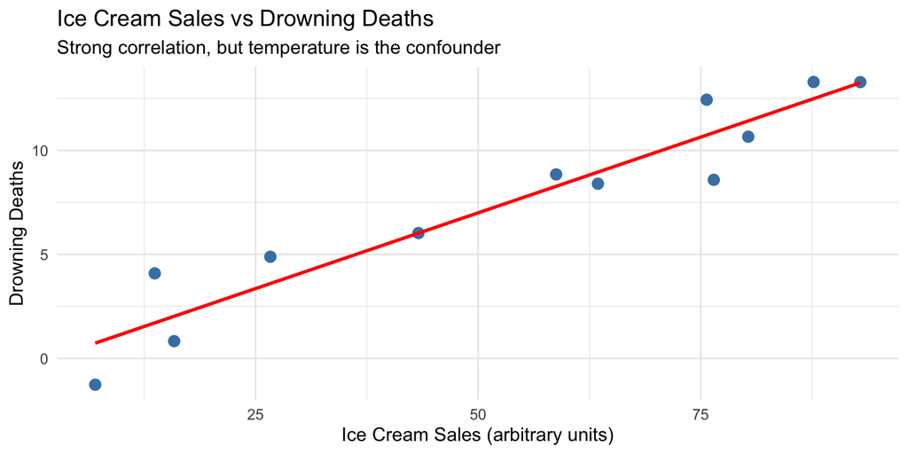

### 4.2.2 Agricultural Example: Pasture Type and Weight Gain

**Scenario**: You visit 20 beef farms. Some use Pasture A (fescue), others use Pasture B (mixed grass). You record average daily gain (ADG) for cattle on each farm.

**Observation**: Cattle on Pasture A have higher ADG.

**Can you conclude Pasture A is better?**

**Probably not!** Possible confounders:

- **Farm quality**: Better-managed farms might choose Pasture A (and also have better nutrition, genetics, health)
- **Soil quality**: Farms with better soil grow Pasture A, but soil quality also affects other forages
- **Region**: Pasture A might be used in regions with better climate for cattle
- **Genetics**: Farms using Pasture A might also use superior genetics

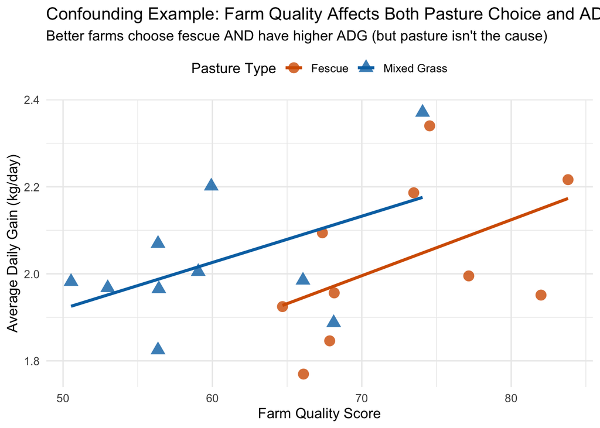

```r
# Simulate pasture study with confounding
set.seed(987)
n_farms <- 20

pasture_data <- tibble(
  farm = 1:n_farms,
  pasture_type = rep(c("Fescue", "Mixed Grass"), each = 10)
) %>%
  mutate(
    # Farm quality is confounder: better farms choose fescue
    farm_quality = ifelse(pasture_type == "Fescue",
                         rnorm(n_farms/2, mean = 75, sd = 8),
                         rnorm(n_farms/2, mean = 60, sd = 8)),
    # ADG depends on farm quality, NOT pasture type!
    adg = 1.2 + 0.012 * farm_quality + rnorm(n_farms, mean = 0, sd = 0.15)
  )

# Visualize the confounding
p6 <- ggplot(pasture_data, aes(x = farm_quality, y = adg, color = pasture_type, shape = pasture_type)) +
  geom_point(size = 4, alpha = 0.8) +
  geom_smooth(method = "lm", se = FALSE, linewidth = 1.2) +
  scale_color_manual(values = c("Fescue" = "#D55E00", "Mixed Grass" = "#0072B2")) +
  labs(
    title = "Confounding Example: Farm Quality Affects Both Pasture Choice and ADG",
    subtitle = "Better farms choose fescue AND have higher ADG (but pasture isn't the cause)",
    x = "Farm Quality Score",
    y = "Average Daily Gain (kg/day)",
    color = "Pasture Type",
    shape = "Pasture Type"
  ) +
  theme(legend.position = "top")

print(p6)
```

```r
# Naive comparison
pasture_data %>%
  group_by(pasture_type) %>%
  summarise(mean_adg = mean(adg), .groups = 'drop') %>%
  knitr::kable(digits = 3, col.names = c("Pasture Type", "Mean ADG (kg/day)"))
```

| Pasture Type | Mean ADG (kg/day) |
| --- | --- |
| Fescue | 2.028 |
| Mixed Grass | 2.026 |

**WarningHow to Address Confounding**

**In observational studies:**

- Statistical adjustment (multiple regression, matching, stratification)
- Careful measurement of potential confounders
- Acknowledge limitations in conclusions

**In experimental studies:**

- **Randomization** (the gold standard—discussed next!)
- Blocking/stratification
- Standardizing all other conditions

# 5 Randomized Controlled Trials (RCTs)

The **randomized controlled trial (RCT)** is the gold standard for establishing causation. It’s an experimental design where:

1. Participants (animals) are **randomly assigned** to treatment groups
2. One group receives the intervention, another serves as a **control**
3. All other conditions are kept as similar as possible
4. Outcomes are measured and compared

## 5.1 Why Randomization is Powerful

**Random assignment** ensures that treatment groups are **balanced** on all variables—both measured and unmeasured—**on average**.

This is crucial because:

- You can’t measure every potential confounder
- You don’t always know what the confounders are
- Randomization balances them automatically (in expectation)

### 5.1.1 Mathematical Intuition

When you randomly assign $n$ animals to groups, every animal has an equal probability of being in any group. This means:

$$E[\text{Confounder}_{\text{Treatment}}] = E[\text{Confounder}_{\text{Control}}]$$

Where $E[\cdot]$ denotes expected value (average across many repetitions).

**In plain English**: On average, the treatment and control groups will have the same distribution of age, weight, genetics, health status, etc.—even if you don’t measure these variables!

## 5.2 Key Features of RCTs

### 5.2.1 1. Random Assignment

Not “haphazard” or “arbitrary”—**random** using a chance mechanism (coin flip, random number generator, etc.).

**Example**: 60 pigs, 30 to each group

```r
set.seed(2025)

# Start with 60 pigs with various characteristics
pigs <- tibble(
  pig_id = 1:60,
  initial_weight = rnorm(60, mean = 25, sd = 4),
  age_days = round(runif(60, min = 50, max = 70)),
  sex = sample(c("Male", "Female"), 60, replace = TRUE),
  litter = sample(1:15, 60, replace = TRUE)
)

# RANDOMLY assign to treatment
pigs <- pigs %>%
  mutate(treatment = sample(rep(c("Control", "Probiotic"), each = 30)))

# Check balance
pigs %>%
  group_by(treatment) %>%
  summarise(
    n = n(),
    mean_weight = mean(initial_weight),
    mean_age = mean(age_days),
    prop_male = mean(sex == "Male"),
    .groups = 'drop'
  ) %>%
  knitr::kable(digits = 2,
               col.names = c("Treatment", "N", "Mean Weight (kg)",
                            "Mean Age (days)", "Proportion Male"))
```

| Treatment | N | Mean Weight (kg) | Mean Age (days) | Proportion Male |
| --- | --- | --- | --- | --- |
| Control | 30 | 25.19 | 60.97 | 0.47 |
| Probiotic | 30 | 25.89 | 59.77 | 0.37 |

Notice how the groups are similar on all measured characteristics—that’s randomization working!

### 5.2.2 2. Control Group

The control group provides the **counterfactual**: what would have happened without the treatment?

Types of controls:

- **Negative control**: No treatment (or placebo)
- **Positive control**: Standard treatment (if testing a new alternative)
- **Multiple controls**: Compare several treatments

### 5.2.3 3. Blinding (when possible)

**Blinding** means keeping the treatment assignment hidden to reduce bias:

- **Single-blind**: Animals (or caretakers) don’t know which group receives which treatment
- **Double-blind**: Neither caretakers nor researchers analyzing data know

**Example**: In a drug trial for cattle, identical-looking pills (one with drug, one placebo) prevent the farm workers from treating groups differently.

**Note**: Blinding isn’t always possible in animal science (e.g., you can’t hide which diet an animal is eating), but controlling for observer bias is still important.

### 5.2.4 4. Standardization

Keep all other conditions **identical** between groups:

- Same housing
- Same feeding schedule
- Same environmental conditions
- Same outcome measurement procedures